# R Schnittstellen - Versionsverwaltung und Applikationen

Jan-Philipp Kolb

9 Mai 2017

# Versionsverwaltung

# [Wozu überhaupt Versionskontrolle?](http://r-bio.github.io/intro-git-rstudio/)

# [Warum Versionskontrolle?](https://git-scm.com/book/de/v1/Los-geht%E2%80%99s-Wozu-Versionskontrolle%3F)

- Versionskontrollsysteme (VCS) protokollieren Änderungen an einer Datei oder einer Anzahl von Dateien über die Zeit hinweg

[Wikipedia Artikel zu Versionsverwaltung](https://de.wikipedia.org/wiki/Versionsverwaltung)

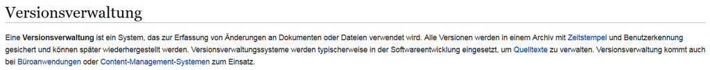

# [Gründe für die Nutzung von Versionskontrolle](http://stackoverflow.com/questions/1408450/why-should-i-use-version-control)

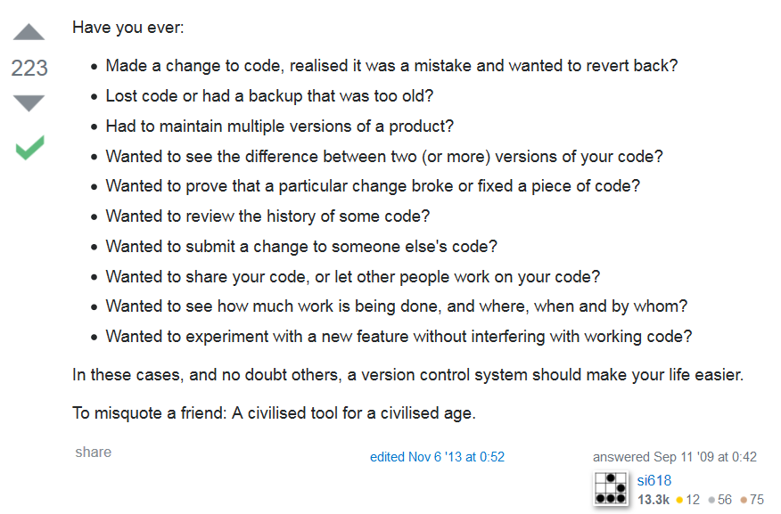

# [GitHub](https://github.com/)

[figure not shown]

# [GitHub Konferenz](https://githubuniverse.com/satellite/?utm_source=github&utm_medium=banner&utm_campaign=ww-satellite-20170405)

London 22 und 23 Mai 2017

[figure not shown]

# [GitLab](https://about.gitlab.com/)

[figure not shown]

# [Git installieren](https://support.rstudio.com/hc/en-us/articles/200532077-Version-Control-with-Git-and-SVN)

- Windows und OS X:

http://git-scm.com/downloads

- Debian/Ubuntu:

```
sudo apt-get install git-core
```

- Fedora/RedHat:

```
sudo yum install git-core
```

# Links

- [Gründe eines Sozialwissenschaftlers Versionskontrolle zu nutzen](http://stackoverflow.com/questions/2712421/r-and-version-control-for-the-solo-data-analyst)
- [Git Bootcamp](https://help.github.com/articles/set-up-git/)

# R und Git

# Rstudio und git - ein Projekt anlegen

[figure not shown]

# Ein Projekt mit Versionskontrolle

[figure not shown]

# Auswahl Versionskontrolle

[figure not shown]

# Ein Projekt clonen

[figure not shown]

# Der git-Reiter in Rstudio

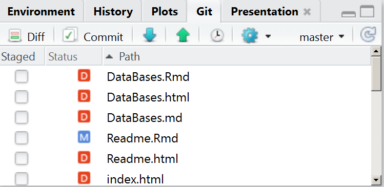

# Aktuelle eigene Änderungen committen

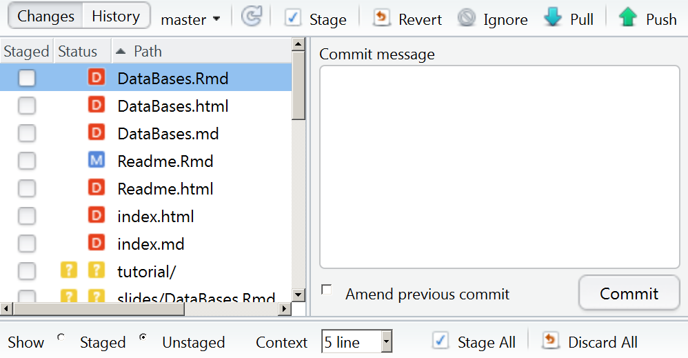

# Der übliche Ablauf

- Datei bearbeiten und speichern
- Änderungen commiten
- Änderungen von anderen ziehen (pull)
- Eigene Änderung hochladen (push)

# Links

- [Commit failed - git shell](http://stackoverflow.com/questions/11229843/github-windows-commit-failed-failed-to-create-a-new-commit)
- [Git cheatsheet](https://services.github.com/on-demand/downloads/github-git-cheat-sheet.pdf)

# Commands

```
git commit
```

```
git push
```

http://stackoverflow.com/questions/1125968/force-git-to-overwrite-local-files-on-pull

# Problems with disk space

[WinDirStat](http://www.tecchannel.de/storage/tools/2037869/mit_windirstat_kostenlos_speicherplatz_auf_der_festplatte_visualisieren/) https://support.microsoft.com/de-de/kb/912997 http://www.pcwelt.de/tipps/Update-Dateien-loeschen-8357046.html

# [Quelle für Pakete](https://www.researchgate.net/figure/301746965_fig1_Figure-2-Number-of-R-packages-by-source)

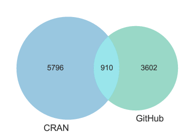

# Ein Paket von Github installieren

```r
install.packages("devtools")
library(devtools)
install_github("Japhilko/gosmd")
```

# Datensätze Suchfunktion

[figure not shown]

# [Git und Rstudio](https://www.r-bloggers.com/version-control-file-sharing-and-collaboration-using-github-and-rstudio/)

[figure not shown]

# Links

- [Using github and rstudio](https://www.r-bloggers.com/version-control-file-sharing-and-collaboration-using-github-and-rstudio/)
- [How do I tell Git for Windows where to find my private RSA key](http://serverfault.com/questions/194567/how-do-i-tell-git-for-windows-where-to-find-my-private-rsa-key)
- [Reset local repository branch to be just like remote repository HEAD](http://stackoverflow.com/questions/1628088/reset-local-repository-branch-to-be-just-like-remote-repository-head)
- [How I Manage Data Analysis Projects with RStudio and Git - Part 1](http://christianlemp.com/blog/2014/02/05/How-I-Manage-Data-Projects-with-RStudio-and-Git.html)
- [How do I force “git pull” to overwrite local files?](http://stackoverflow.com/questions/1125968/how-do-i-force-git-pull-to-overwrite-local-files)

# Shiny Apps

# Das `shiny` Paket installieren

```r
install.packages("shiny")
```

[figure not shown]

# Wer hat’s erfunden?

```r
citation("shiny")
```

```
##
##
##   Winston Chang, Joe Cheng, JJ Allaire, Yihui Xie and Jonathan
##   McPherson (2017). shiny: Web Application Framework for R. R
##   package version 1.0.1. https://CRAN.R-project.org/package=shiny
##
## A BibTeX entry for LaTeX users is
##
##   @Manual{,
##     title = {shiny: Web Application Framework for R},
##     author = {Winston Chang and Joe Cheng and JJ Allaire and Yihui Xie and Jonathan McPherson},
##     year = {2017},
##     note = {R package version 1.0.1},
##     url = {https://CRAN.R-project.org/package=shiny},
##   }
```

# Eine erste Beispielapp

```r
library(shiny)
runExample("01_hello")
```

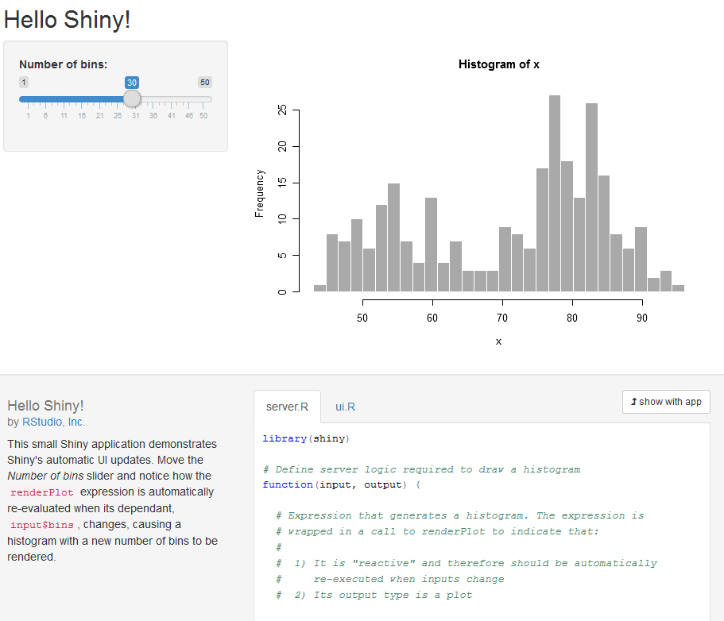

# Der Start

[figure not shown]

# Dem Kind einen Namen geben

[figure not shown]

# Die erste App

- man muss den Run App Button drücken
- Das Ergebnis:

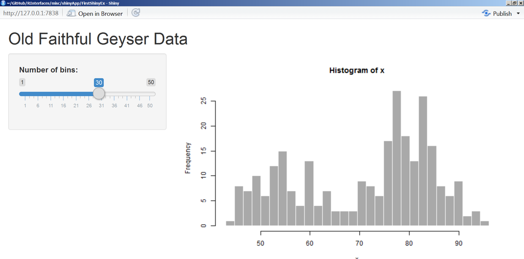

# Zur Erklärung

- Zumeist arbeitet man mit mindestens zwei Dateien
- Das user interface wird mit einer Datei erzeugt werden, die `ui.R` genannt werden muss
- Für die Server Seite brauchen wir auch ein eigenes File, dieses bennenen wir mit `server.R`

# Eine zweite Beispiel App

```r
library(shiny)
runExample("02_text")
```

[figure not shown]

# [Einführung in Shiny](https://shiny.rstudio.com/tutorial/)

[figure not shown]

# Links

- [Eine Dashboard App erzeugen](https://shiny.rstudio.com/tutorial/js-lesson1/#creating-a-dashboard-app)